# Metabolomics data pre-processing using xcms

Johannes Rainer

Institute for Biomedicine, Eurac Research, Bolzano, Italy

12 July 2018

# 1 Abstract

In this document we discuss general MS data access concepts using Bioconductor’s `MSnbase` package (Gatto and Lilley 2012) and walk through the preprocessing of an LC-MS toy data set using the `xcms` package (Smith et al. 2006) that comprises chromatographic peak detection, sample alignment and peak correspondence. Particular emphasis is given on the most important settings of popular preprocessing methods and how these can be defined depending on the analyzed data set.

# 2 Introduction

This workflow discusses the first step in the analysis of an LC-MS-based untargeted metabolomics experiment. If you have any comments, suggestions, find typos or want to provide general feedback you are welcome to open an issue at the workshop’s repository at [jo’s CSAMA contributions](https://github.com/jotsetung/jos-csama-contributions).

## 2.1 Prerequisites

The analysis in this document requires an R version >= 3.5.0 and recent versions of the `MSnbase` and `xcms` (version >= 3.3.1 is needed) packages. Since at the CSAMA 2018 course site only limited internet connectivity is available, we install packages from the local network if required.

```r
## Install required packages from the local repository
source("http://192.168.0.5/biocLite.R")
biocLite(c("xcms", "MSnbase", "doParallel", "msdata", "magrittr",
           "devtools"))
```

## 2.2 Mass spectrometry

Mass spectrometry allows to measure abundances of charged ions in a sample. Abundances are determined as ion counts for a specific mass-to-charge ratio m/z. The measured signal is represented in a spectrum, intensities along m/z.

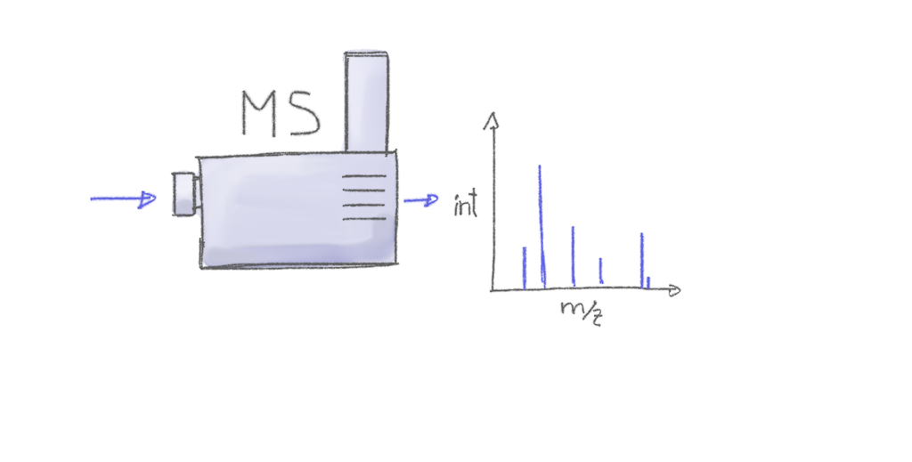

Many ions have the same or a very similar m/z and MS is thus frequently coupled with a second technology to separate the analytes based on other properties than their charge (e.g. hydrophilic/hydrophobic). Common choices are gas chromatography (GC) or liquid chromatography (LC). Such a e.g. LC-MS setup performs thus scans at discrete time points resulting in a set of spectra for a given sample, with compounds separated both on m/z and on retention time dimension.

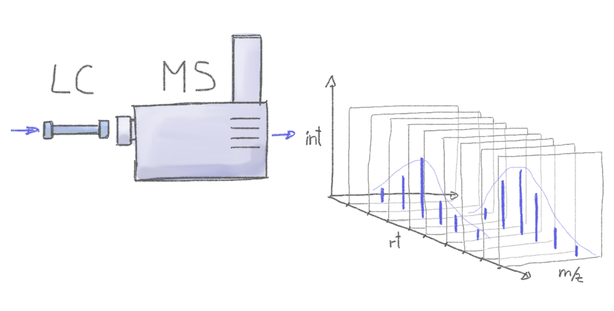

In LC-MS data analysis ions are quantified by identifying and integrating signal from *chromatographic* peaks.

## 2.3 Definitions and common naming convention

Naming conventions and terms used throughout this document are:

- chromatographic peak: peak containing the signal from an ion in retention time dimension (different from a *mass* peak that represents the signal along the m/z dimension within a spectrum.
- chromatographic peak detection: process in which chromatographic peaks are identified within each file.
- alignment: process that adjusts for retention time differences between files.
- correspondence: grouping of chromatographic peaks (presumably from the same ion) across files.
- feature: chromatographic peaks grouped across files.

# 3 Workflow: metabolomics data preprocessing using `xcms`

This workflow describes the basic data handling (I/O) of mass spectrometry data using the `MSnbase` package, and the LC/GC-MS data preprocessing using `xcms`. It showcases the new functionality and user interface functions of `xcms`, that re-use functionality from the `MSnbase` package. The first part of the workflow is focused on data import, access and visualization followed by the description of a simple data centroiding approach and concluded by the `xcms`-based LC-MS data preprocessing that comprises chromatographic peak detection, alignment and correspondence. The workflow does not cover data normalization procedures, compound identification and differential abundance analysis.

## 3.1 Data import and representation

In the code block below we load all required libraries and read our toy data using the `readMSData` function. This data set consists of two files in mzML format, with signals from pooled human serum samples measured with a ultra high performance liquid chromatography (UHPLC) system (Agilent 1290) coupled with a Q-TOF MS (TripleTOF 5600+ AB Sciex) instrument. Chromatographic separation based on hydrophilic interaction liquid chromatography (HILIC). The system was tuned to allow measurement of the *polar metabolome*. To reduce file sizes, the data set was restricted to an m/z range from 105 to 134 and retention times from 0 to 260 seconds. We also define a `data.frame` describing the experiment and pass this to the `readMSData` function. We thus have all experiment-related information within the same data object. The option `mode = "onDisk"` tells the function to read only general metadata into memory. The m/z and intensity values from the original files are not kept in memory, but retrieved from the original files on demand. This enables analyses also of very large experiments.

```r
library(MSnbase)
library(xcms)
library(doParallel)
library(magrittr)

## Define the file names.
fls <- dir(system.file("sciex", package = "msdata"), full.names = TRUE)

## Define a data.frame with additional information on the files.
pd <- data.frame(file = basename(fls),
                 injection_idx = c(1, 19),
                 sample = c("POOL_1", "POOL_2"),
                 group = "POOL")
data <- readMSData(fls, pdata = new("NAnnotatedDataFrame", pd),
                   mode = "onDisk")
```

Next we set up parallel processing. This ensures that all required cores are registered and available from the beginning of the analysis. All data access and analysis functions of `xcms` and `MSnbase` are parallelized on a per-file basis and will use this setup by default.

```r
## Set up parallel processing using 2 cores
registerDoParallel(2)
register(bpstart(DoparParam()), default = TRUE)
```

The MS experiment data is now represented as an `OnDiskMSnExp` object. Phenotype information can be retrieved with the `pData` function, or directly using `$`. Below we access sample descriptions.

```r
## Access phenotype information
pData(data)
```

```
##                               file injection_idx sample group
## 1 20171016_POOL_POS_1_105-134.mzML             1 POOL_1  POOL
## 2 20171016_POOL_POS_3_105-134.mzML            19 POOL_2  POOL
```

```r
## Or individual columns directly using the $ operator
data$injection_idx
```

```
## [1]  1 19
```

General information on each spectrum in the experiment can be accessed with the `fData` function, that returns a `data.frame` with one row per spectrum.

```r
## Access spectrum header information
head(fData(data))
```

```
##         fileIdx spIdx smoothed seqNum acquisitionNum msLevel polarity
## F1.S001       1     1       NA      1              1       1        1
## F1.S002       1     2       NA      2              2       1        1
## F1.S003       1     3       NA      3              3       1        1
## F1.S004       1     4       NA      4              4       1        1
## F1.S005       1     5       NA      5              5       1        1
## F1.S006       1     6       NA      6              6       1        1
##         originalPeaksCount totIonCurrent retentionTime basePeakMZ
## F1.S001                578        898185         0.280   124.0860
## F1.S002               1529       1037012         0.559   124.0859
## F1.S003               1600       1094971         0.838   124.0859
## F1.S004               1664       1135015         1.117   124.0859
## F1.S005               1417       1106233         1.396   124.0859
## F1.S006               1602       1181489         1.675   124.0859
##         basePeakIntensity collisionEnergy ionisationEnergy    lowMZ   highMZ
## F1.S001            154089               0                0 105.0435 133.9837
## F1.S002            182690               0                0 105.0275 133.9836
## F1.S003            196650               0                0 105.0376 133.9902
## F1.S004            203502               0                0 105.0376 133.9853
## F1.S005            191715               0                0 105.0347 133.9885
## F1.S006            213400               0                0 105.0420 133.9836
##         precursorScanNum precursorMZ precursorCharge precursorIntensity
## F1.S001                0           0               0                  0
## F1.S002                0           0               0                  0
## F1.S003                0           0               0                  0
## F1.S004                0           0               0                  0
## F1.S005                0           0               0                  0
## F1.S006                0           0               0                  0
##         mergedScan mergedResultScanNum mergedResultStartScanNum
## F1.S001          0                   0                        0
## F1.S002          0                   0                        0
## F1.S003          0                   0                        0
## F1.S004          0                   0                        0
## F1.S005          0                   0                        0
## F1.S006          0                   0                        0
##         mergedResultEndScanNum injectionTime filterString
## F1.S001                      0             0         <NA>
## F1.S002                      0             0         <NA>
## F1.S003                      0             0         <NA>
## F1.S004                      0             0         <NA>
## F1.S005                      0             0         <NA>
## F1.S006                      0             0         <NA>
##                                     spectrumId centroided spectrum
## F1.S001 sample=1 period=1 cycle=1 experiment=1      FALSE        1
## F1.S002 sample=1 period=1 cycle=2 experiment=1      FALSE        2
## F1.S003 sample=1 period=1 cycle=3 experiment=1      FALSE        3
## F1.S004 sample=1 period=1 cycle=4 experiment=1      FALSE        4
## F1.S005 sample=1 period=1 cycle=5 experiment=1      FALSE        5
## F1.S006 sample=1 period=1 cycle=6 experiment=1      FALSE        6
```

## 3.2 Basic data access and visualization

The MS data in an `OnDiskMSnExp` object is organized by spectrum (similar as in *mzML* files), with `Spectrum` objects used as containers for the m/z and intensity values. General spectrum information can be retrieved using the `msLevel`, `centroided`, `rtime` or `polarity` functions that return the respective value for all spectra from all files. Here, the `fromFile` function can be helpful to determine from which file/sample the information comes. This is shown in the code block below.

```r
## Get the retention time
head(rtime(data))
```

```
## F1.S001 F1.S002 F1.S003 F1.S004 F1.S005 F1.S006
##   0.280   0.559   0.838   1.117   1.396   1.675
```

```r
## Get the retention times splitted by file.
rts <- split(rtime(data), fromFile(data))

## The result is a list of length 2. The number of spectra per file can
## then be determined with
lengths(rts)
```

```
##   1   2
## 931 931
```

The `spectra` function can be used to retrieve the list of all spectra (from all files). This will load the full data from all raw files, which can take, depending on the size of the files and number of spectra, a relatively long time and requires, depending on the experiment, a considerable amount of memory. In most cases we will however work anyway with sub-sets of the data, and retrieving such data can, in the case of indexed mzML, mzXML and CDF files, be very fast. Data objects can be easily subsetted using the filter functions: `filterFile`, `filterRtime`, `filterMz` or `filterMsLevel` that filter the data by file, retention time range, m/z range or MS level. To illustrate this we retrieve below all spectra measured between 180 and 181 seconds. Note that we use the pipe operator `%>%` from the `magrittr` package for better readability.

```r
## Get all spectra measured between 180 and 181 seconds
## Use %>% to avoid nested function calls
sps <- data %>%
    filterRt(rt = c(180, 181)) %>%
    spectra
```

The result is a `list` of `Spectrum` objects. Below we determine the number of spectra we have got.

```r
## How many spectra?
length(sps)
```

```
## [1] 6
```

We can use the `fromFile` function to determine from which file/sample each spectrum is.

```r
## From which file?
sapply(sps, fromFile)
```

```
## F1.S646 F1.S647 F1.S648 F2.S646 F2.S647 F2.S648
##       1       1       1       2       2       2
```

We have thus 3 spectra per file. Next we plot the data from the last spectrum (i.e. the 3rd spectrum in the present retention time window from the second file).

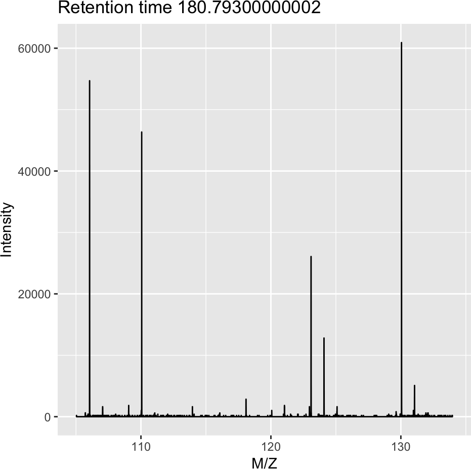

Figure 1: Spectrum at a retention time of about 180 seconds

```r
plot(sps[[6]])
```

We can immediately spot several mass peaks in the spectrum, with the largest one at a m/z of about 130 and the second largest at about 106, which matches the expected mass to charge ratio for the [M+H]+ adduct of Serine.

MS data is in general organized by spectrum, but in LC-MS experiments we analyze the data along the retention time axis and hence orthogonally to this data representation. To extract such data we can use the `chromatogram` function. The function aggregates intensities for each scan/retention time along the m/z axis (i.e. within each spectrum) and returns the retention time - intensity duplets in a `Chromatogram` object, one per file. The `Chromatogram` object supports, similar to the `Spectrum` object, the `rtime` and `intensity` functions to access the respective data. Below we use the `chromatogram` function to extract the total ion chromatogram (TIC) for each file and plot it.

```r
## Get chromatographic data (TIC) for an m/z slice
chr <- chromatogram(data)
chr
```

```
## Chromatograms with 1 row and 2 columns
##                   1              2
##      <Chromatogram> <Chromatogram>
## [1,]    length: 931    length: 931
## phenoData with 4 variables
## featureData with 1 variables
```

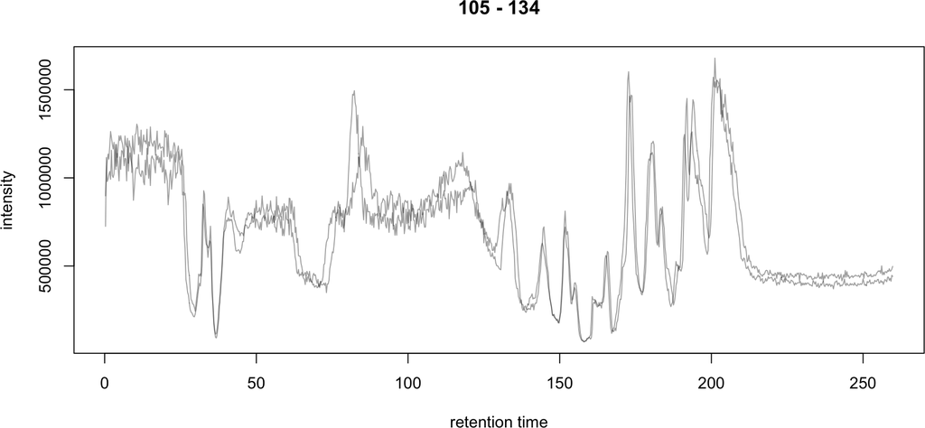

Figure 2: Total ion chromatogram

```r
## Plot the tic
plot(chr)
```

The object returned by the `chromatogram` function arranges the individual `Chromatogram` objects in a two-dimensional array, columns being samples (files) and rows data slices. Below we extract the (total ion) intensities from the TIC of the first file.

```r
ints <- intensity(chr[1, 1])
head(ints)
```

```
## F1.S001 F1.S002 F1.S003 F1.S004 F1.S005 F1.S006
##  898185 1037012 1094971 1135015 1106233 1181489
```

The object contains also all phenotype information from the original `data` variable. This can be accessed in the same way than for `OnDiskMSnExp` objects (or most other data objects in Bioconductor).

```r
## Access the full phenotype data
pData(chr)
```

```
##                               file injection_idx sample group
## 1 20171016_POOL_POS_1_105-134.mzML             1 POOL_1  POOL
## 2 20171016_POOL_POS_3_105-134.mzML            19 POOL_2  POOL
```

Depending on the parameter `aggregationFun`, the function can produce total ion chromatograms (TIC), with `aggregationFun = "sum"` or base peak chromatograms (BPC) with `aggregationFun = "max"`. Below we extract and plot the ion chromatogram for Serine after first filtering the data object to the retention time and by m/z ranges containing the signal for this compound.

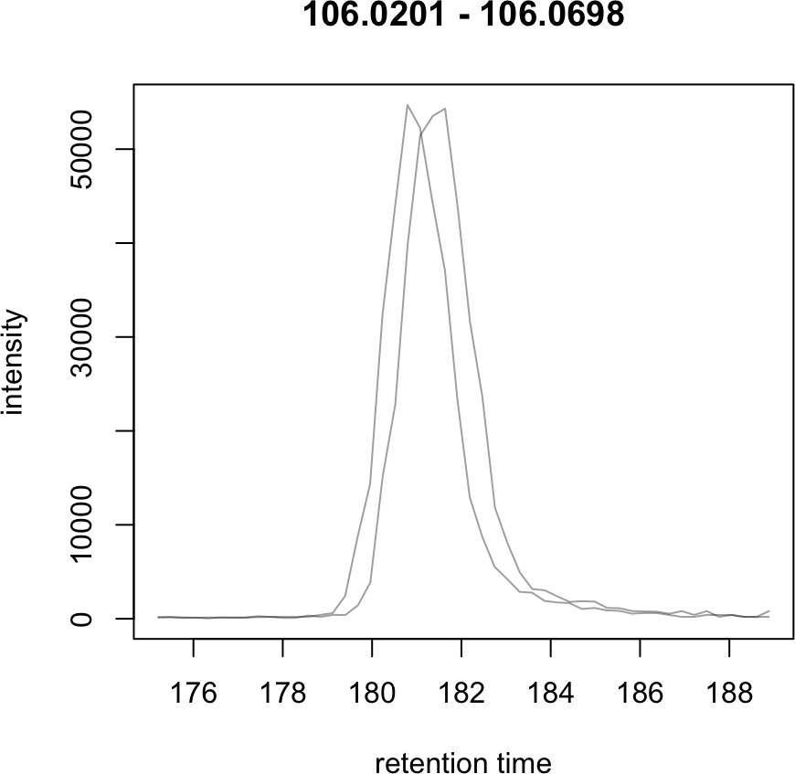

Figure 3: Extracted ion chromatogram for the Serine [M+H]+ ion in both files

```r
## Extract and plot the XIC for Serine
data %>%
    filterRt(rt = c(175, 189)) %>%
    filterMz(mz = c(106.02, 106.07)) %>%
    chromatogram(aggregationFun = "max") %>%
    plot()
```

## 3.3 Centroiding of profile MS data

MS instruments allow to export data in profile or centroid mode. Profile data contains the signal for all discrete m/z values (and retention times) for which the instrument collected data (Smith et al. 2014). For each ion at a given retention time the instrument measures thus multiple intensities, at m/z values that are distributed around the ion’s *real* m/z value. Centroiding is the process to reduce these mass peaks to a single representative signal, the centroid. `xcms`, specifically the *centWave* chromatographic peak detection algorithm, was designed for centroided data, thus, prior to data analysis, profile data should be centroided. The `MSnbase` package provides the basic toolset to perform centroiding (and data smoothing): `pickPeaks` and `smooth`.

Below we inspect the profile data for the [M+H]+ ion adduct of Serine. We subset the data to the m/z and retention time range containing signal from Serine and `plot` the data with `type = "XIC"`, that generates a combined chromatographic and *map* visualization of the data (i.e. a plot of the individual m/z, rt and intensity data tuples with data points colored by their intensity in the m/z - retention time space).

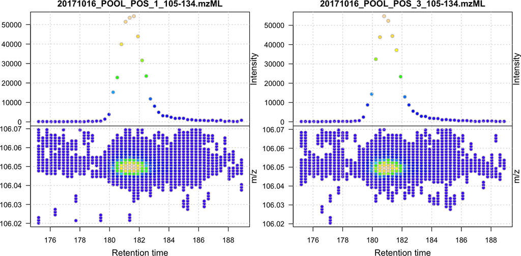

Figure 4: Profile data for Serine

```r
## Filter the MS data to the signal from the Serine ion and plot it using
## type = "XIC"
data %>%
    filterRt(rt = c(175, 189)) %>%
    filterMz(mz = c(106.02, 106.07)) %>%
    plot(type = "XIC")
```

The plot shows all data points measured by the instrument. It clearly shows the mass peaks for Serine, that are represented by a distribution of signal in both retention time and m/z dimension.

Next we smooth the data in each spectrum using a Savitzky-Golay filter, which usually improves data quality by reducing noise. Subsequently we perform a centroiding analysis based on a simple peak-picking strategy that reports the maximum signal for each mass peak in each spectrum.

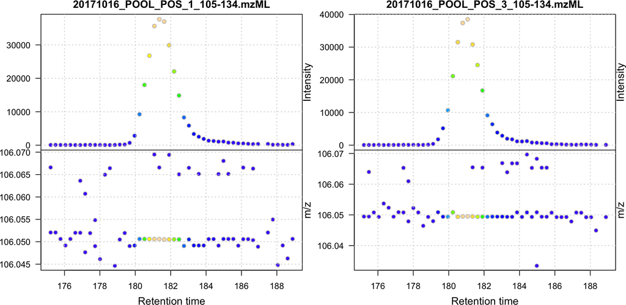

Figure 5: Centroided data for Serine

```r
## Smooth the signal, then do a simple peak picking.
data_cent <- data %>%
    smooth(method = "SavitzkyGolay", halfWindowSize = 6) %>%
    pickPeaks()

## Plot the centroided data for Serine
data_cent %>%
    filterRt(rt = c(175, 189)) %>%
    filterMz(mz = c(106.02, 106.07)) %>%
    plot(type = "XIC")
```

As expected, centroiding successfully reduced the data to a single data point for an ion in each spectrum. For more advanced centroiding options that also fine-tune the m/z value of the reported centroid see the `pickPeaks` help or the centroiding vignette in `MSnbase`.

Note that, since the MS data is not loaded in memory, smoothing and centroiding is applied to the data *on-the-fly* each time that m/z or intensity values are requested from the data object `data_cent`. To make any data manipulation on an `OnDiskMSnExp` object *persistent* we need to export and re-read the data. Below we save thus the centroided data as mzML files and read the exported data again.

```r
## Write the centroided data to files with the same names in the current
## directory
fls_new <- basename(fileNames(data))
writeMSData(data_cent, file = fls_new)

## Read the centroided data.
data_cent <- readMSData(fls_new, pdata = new("NAnnotatedDataFrame", pd),
                        mode = "onDisk")
```

## 3.4 LC-MS data preprocessing

### 3.4.1 Chromatographic peak detection

Chromatographic peak detection aims to identify peaks along the retention time axis that represent the signal from individual compounds’ ions. This can be performed with the `findChromPeaks` function and one of different algorithms that are selected depending on the submitted parameter object: with `MatchedFilterParam` it performs peak detection as described in the original xcms article (Smith et al. 2006). With `CentWaveParam` a continuous wavelet transformation (CWT)-based peak detection is performed that can detect close-by and partially overlapping peaks with different widths (Tautenhahn, Böttcher, and Neumann 2008). With `MassifquantParam` it performs a Kalman filter-based peak detection (Conley et al. 2014). Additional peak detection algorithms for direct injection data are also available, but not discussed here.

We use the *centWave* algorithm that performs peak detection in two steps: first it identifies regions of interest in the m/z - retention time space and subsequently detects peaks in these regions using a continuous wavelet transform (see the original publication for more details). centWave can be configured with several parameters (see `?CentWaveParam`), with the most important ones being `peakwidth` and `ppm`. `peakwidth` defines the minimal and maximal expected width of the peak in retention time dimension and depends thus on the LC setting of the LC-MS system used to measure the data. Appropriate values for this parameter can be defined based on extracted ion chromatograms of known compounds. Below we extract chromatographic data for Serine and perform a peak detection on the `Chromatogram` object using the default parameters for centWave.

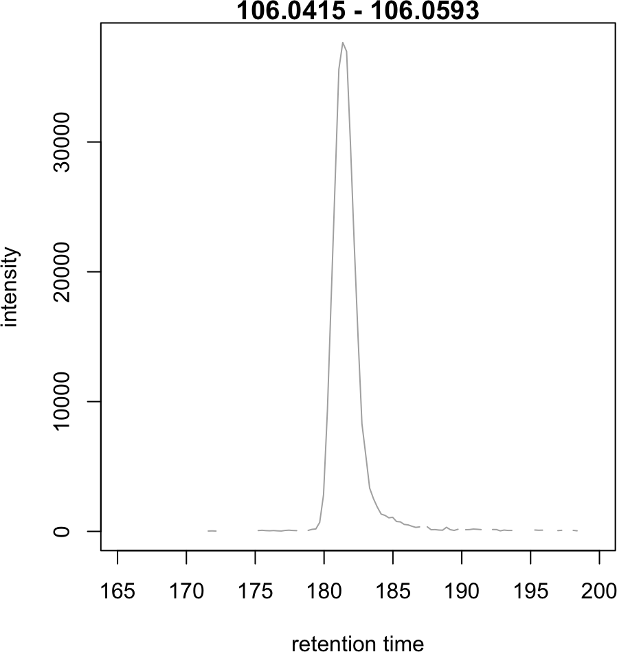

Figure 6: XIC for Serine

```r
## Get the XIC for serine in the first file
srn_chr <- chromatogram(data_cent, rt = c(165, 200),
                        mz = c(106.03, 106.06),
                        aggregationFun = "max")[1, 1]
## Plot the data
par(mfrow = c(1, 1), mar = c(4, 4.5, 1, 1))
plot(srn_chr)
```

```r
## Get default centWave parameters
cwp <- CentWaveParam()

## "dry-run" peak detection on the XIC.
findChromPeaks(srn_chr, param = cwp)
```

```r
cwp
```

```
## Object of class:  CentWaveParam
## Parameters:
##  ppm: 25
##  peakwidth: 20, 50
##  snthresh: 10
##  prefilter: 3, 100
##  mzCenterFun: wMean
##  integrate: 1
##  mzdiff: -0.001
##  fitgauss: FALSE
##  noise: 0
##  verboseColumns: FALSE
##  roiList length: 0
##  firstBaselineCheck TRUE
##  roiScales length: 0
```

The default settings for `peakwidth` are 20 to 50 seconds, while from the plot above it is apparent that the chromatographic peak for Serine is about 4 seconds wide. Below we adapt the settings to accommodate peaks ranging from 2 to 10 seconds and re-run the peak detection. In general, it is advised to investigate peak widths for several ions in the data set to determine the most appropriate `peakwidth` setting.

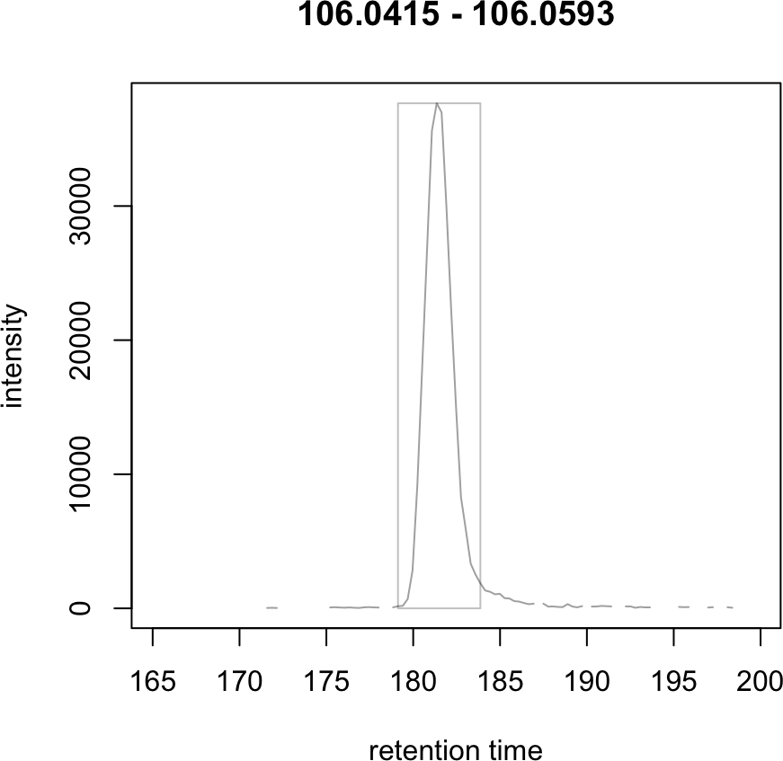

Figure 7: XIC for Serine with detected chromatographic peak

```r
cwp <- CentWaveParam(peakwidth = c(2, 10))

pks <- findChromPeaks(srn_chr, param = cwp)

## Plot the data and higlight identified peak area
plot(srn_chr)
rect(pks[, "rtmin"], 0, pks[, "rtmax"], pks[, "maxo"], border = "#00000040")
```

Another important parameter is `ppm` which is used in the initial identification of the regions of interest. In contrast to random noise, the *real* signal from an ion is expected to yield stable m/z values in consecutive scans (the scattering of the m/z values around the *real* m/z value of the ion is supposed to be inversely related with its intensity). In centWave, all data points that differ by less than `ppm` in consecutive spectra are combined into a region of interest that is then subject for the CWT-based peak detection. To illustrate this, we plot the full data for Serine.

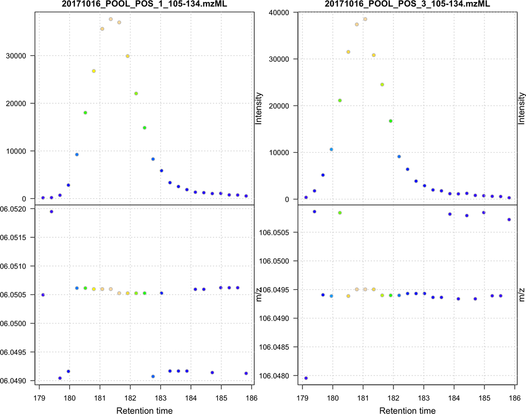

```r
## Restrict the data to signal from Sering
srn <- data_cent %>%
    filterRt(rt = c(179, 186)) %>%
    filterMz(mz = c(106.04, 106.06))

## Plot the data
plot(srn, type = "XIC")
```

As expected, higher intensity signals tend to scatter less in m/z dimension. We next calculate the differences in m/z values between consecutive scans in this data subset.

```r
## Extract the Serine data for one file as a data.frame
srn_df <- as(filterFile(srn, 1), "data.frame")

## The difference between m/z values from consecutive scans expressed
## in ppm
diff(srn_df$mz) * 1e6 / mean(srn_df$mz)
```

```
##  [1]  13.695973646 -27.391665930   1.112565444  13.695804399   0.000000000
##  [6]  -0.158840806   0.000000000   0.000000000  -0.682098923   0.000000000
## [11]   0.000000000   0.007189239 -13.695795336  13.695795336 -12.807200180
## [16]   0.000000000   0.000000000  13.443799681   0.000000000 -13.695795190
## [21]  13.957010392   0.000000000   0.000000000 -14.085629933
```

The difference in m/z values for the Serine data is thus between 0 and 27 ppm. This should ideally be evaluated for several compounds and should be set to a value that allows to capture the full chromatographic peaks for most of the tested compounds. We can next perform the peak detection using our settings for the `ppm` and `peakwidth` parameters.

```r
## Perform peak detection
cwp <- CentWaveParam(peakwidth = c(2, 10), ppm = 30)
data_cent <- findChromPeaks(data_cent, param = cwp)
```

The result from the `findChromPeaks` call is an `XCMSnExp` object which contains all preprocessing results and, by extending the `OnDiskMSnExp` object, inherits all of its functionality that has been described so far. The results from the peak detection analysis can be accessed with the `chromPeaks` function, that, with the optional `rt` and `mz` parameters, allows to extract identified chromatographic peaks from specific areas in the data. Below we extract all identified peaks for a certain m/z - rt area.

```r
## Access the peak detection results from a specific m/z - rt area
chromPeaks(data_cent, mz = c(106, 107), rt = c(150, 190))
```

```
##            mz    mzmin    mzmax      rt   rtmin   rtmax       into
## [1,] 106.0625 106.0606 106.0636 173.264 171.869 175.217   567.5094
## [2,] 106.0506 106.0505 106.0506 181.356 179.124 183.867 71660.1062
## [3,] 106.0633 106.0609 106.0652 172.701 170.469 174.375   558.1327
## [4,] 106.0496 106.0494 106.0508 181.072 178.840 183.304 67756.6562
##            intb       maxo  sn sample is_filled
## [1,]   563.6306   426.6084  46      1         0
## [2,] 71559.5369 37664.9371 751      1         0
## [3,]   553.5792   381.6084  58      2         0
## [4,] 67645.5242 38517.7622 898      2         0
```

For each identified peak the m/z and rt value of the apex is reported (columns “mz” and “rt”) as well as their ranges (“mzmin”, “mzmax”, “rtmin”, “rtmax”), the integrated signal of the peak (i.e. the peak area “into”), the maximal signal of the peak (“maxo”), the signal to noise ratio (“sn”) and the index of the sample in which the peak was detected (“sample”). For quality assessment we could now calculate summary statistics on the identified peaks to e.g. identify samples with much less detected peaks. Also, we can use the `plotChromPeaks` function to provide some general information on the location of the identified chromatographic peaks in the m/z - rt space.

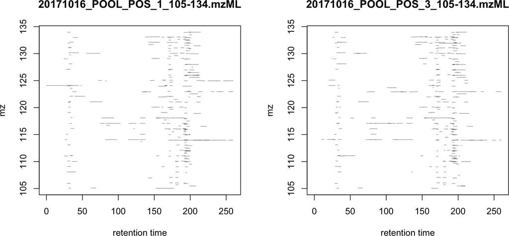

Figure 8: Location of the identified chromatographic peaks in the m/z - rt space

```r
par(mfrow = c(1, 2))
plotChromPeaks(data_cent, 1)
plotChromPeaks(data_cent, 2)
```

### 3.4.2 Alignment

While chromatography helps to discriminate between analytes it is also affected by variances that lead to shifts in retention times between measurement runs. The alignment step aims to adjust these retention time differences between samples in an experiment. Below we plot the base peak chromatograms of both files of our toy data set to visualize these differences.

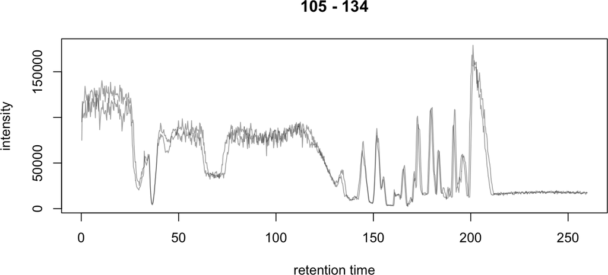

Figure 9: BPC of all files

```r
## Extract base peak chromatograms
bpc_raw <- chromatogram(data_cent, aggregationFun = "max")
plot(bpc_raw)
```

While both samples were measured with the same setup on the same day there are still differences observable in the BPCs above.

Alignment can be performed with `xcms` using the `adjustRtime` function that supports the *peakGroups* (Smith et al. 2006) and the *obiwarp* (Prince and Marcotte 2006) method. The settings for the algorithms can be defined with the `PeakGroupsParam` and the `ObiwarpParam` parameter objects, respectively.

For our example we use the peakGroups method that aligns samples based on the retention times of *hook peaks*, which are supposed to be present in most samples. Prior to alignment we have thus to identify these peaks, which is accomplished by the *peakDensity* correspondence analysis method. Details about this method and explanations on the choices of its parameters are provided in the next section. After having performed this initial correspondence, we perform the alignment using the settings `minFraction = 1` and `span = 0.6`. `minFraction` defines the proportion of samples in which a peak from the peak group (feature) has to be detected/present. A value of 0.9 would e.g. require that a chromatographic peak was detected in 90% of all samples of the experiment. Our data represents replicated measurements of the same sample pool and we can thus assume that for hook peaks a peak was identified in each file. The parameter `span` defines the degree of smoothing of the loess function that is used to allow different regions along the retention time axis to be adjusted by a different factor. A value of 0 will most likely cause overfitting, while 1 would perform a constant, linear shift. Values between 0.4 and 0.6 seem to be reasonable for most experiments.

```r
## Define the settings for the initial peak grouping - details for
## choices in the next section.
pdp <- PeakDensityParam(sampleGroups = data_cent$group, bw = 1.8,
                        minFraction = 1, binSize = 0.02)
data_cent <- groupChromPeaks(data_cent, pdp)

## Define settings for the alignment
pgp <- PeakGroupsParam(minFraction = 1, span = 0.6)
data_cent <- adjustRtime(data_cent, param = pgp)
```

Adjusted retention times are stored, along with the raw retention times, within the result object. Any function accessing retention times (such as `rtime`) will by default return adjusted retention times from an `XCMSnExp` object, if present. Note that also the retention times of the identified chromatographic peaks are adjusted by the `adjustRtime` call. After alignment it is suggested to inspect the differences between raw and adjusted retention times.

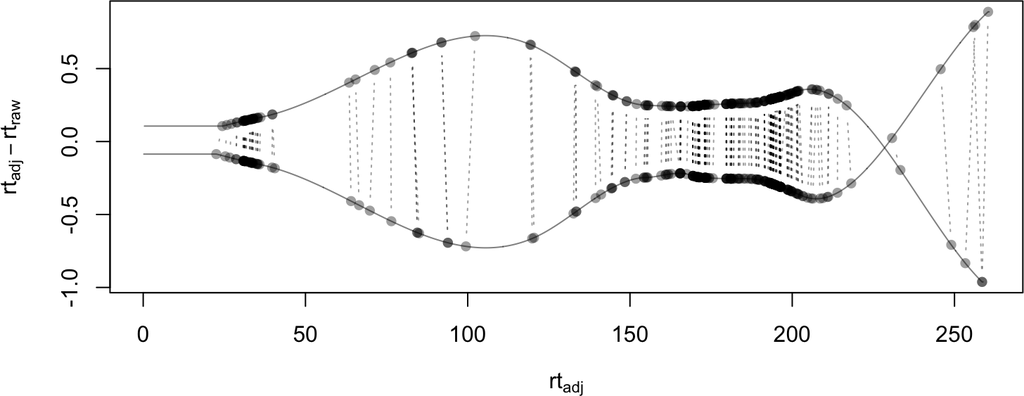

Figure 10: Alignment results  
Shown is the difference between raw and adjusted retention times and the hook peaks that were used for the alignment (shown as points).

```r
## Plot the difference between raw and adjusted retention times
plotAdjustedRtime(data_cent)
```

The difference between raw and adjusted retention time should be reasonable. In our example it is mostly below one second, which is OK since the samples were measured within a short time period and differences are thus expected to be small. Also, hook peaks should ideally be present along the full retention time range. Next we plot the base peak chromatograms before and after alignment to get a general overview of the alignment performance.

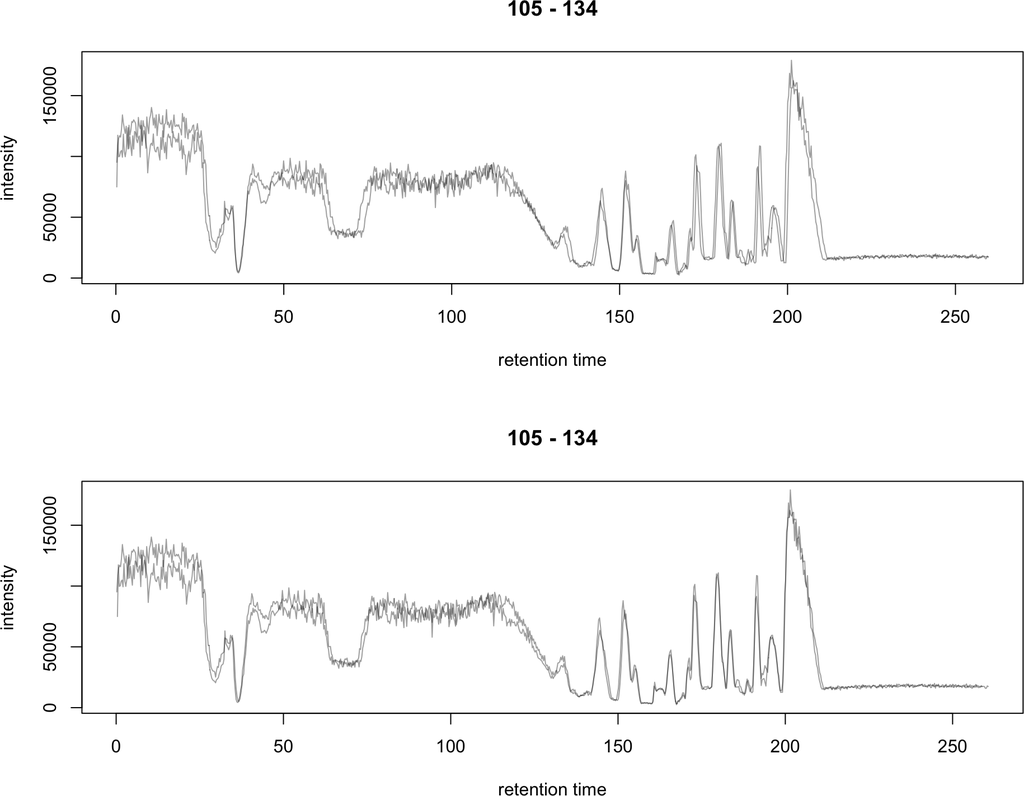

Figure 11: BPC before (top) and after (bottom) alignment

```r
par(mfrow = c(2, 1))
## Plot the raw base peak chromatogram
plot(bpc_raw)
## Plot the BPC after alignment
plot(chromatogram(data_cent, aggregationFun = "max"))
```

The base peak chromatograms are nicely aligned after retention time adjustment. The impact of the alignment should also be evaluated on known compounds. We thus plot below the XIC for Serine before and after alignment.

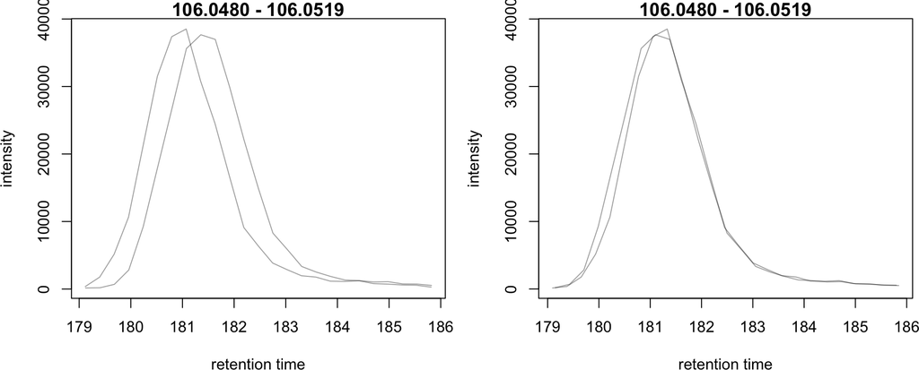

Figure 12: XIC for Serine before (left) and after (right) alignment

```r
## Use adjustedRtime parameter to access raw/adjusted retention times
par(mfrow = c(1, 2), mar = c(4, 4.5, 1, 0.5))
plot(chromatogram(data_cent, mz = c(106.04, 106.06),
                  rt = c(179, 186), adjustedRtime = FALSE))
plot(chromatogram(data_cent, mz = c(106.04, 106.06),
                  rt = c(179, 186)))
```

The Serine peaks are also nicely aligned after adjustment. Note that if we were not happy with the alignment results we could simply retry with different settings after removing old results with the `dropAdjustedRtime` function. This function restores also the original retention times of the identified chromatographic peaks.

### 3.4.3 Correspondence

The final step of the LC-MS preprocessing with `xcms` is the correspondence analysis, in which chromatographic peaks from the same ion are grouped across samples to form a *feature*. `xcms` implements two methods for this purpose: *peak density* (Smith et al. 2006) and *nearest* (Katajamaa, Miettinen, and Oresic 2006) that can be configured by passing either a `PeakDensityParam` or a `NearestPeaksParam` object to the `groupChromPeaks` function. For our example we use the peak density method that iterates through slices of m/z ranges of the data and groups chromatographic peaks in each (within the same or in other samples) if they are close enough in their retention time. Which peaks are grouped together is defined based on the distribution of peaks along the retention time that is estimated with the R `density` function. To illustrate this we extract below an m/z slice containing the Serine peak and use the `plotChromPeakDensity` function to visualize the distribution of peaks along the retention time axis and *simulate* a correspondence based on the provided settings. This function thus allows to test different settings for the correspondence on data subsets before applying them on the full data set.

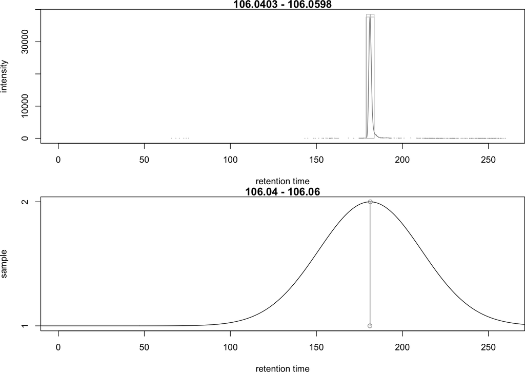

Figure 13: BPC for a m/z slice and defined features within this slice based on default settings

```r
## Plot the BPC for the m/z slice containing serine
par(mfrow = c(2, 1), mar = c(4, 4.3, 1, 0.5))
plot(chromatogram(data_cent, mz = c(106.04, 106.06), aggregationFun = "max"))
highlightChromPeaks(data_cent, mz = c(106.04, 106.06),
                    whichPeaks = "apex_within")

## Get default parameters for the grouping
pdp <- PeakDensityParam(sampleGroups = data_cent$group)

## Dry-run correspondence and show the results.
plotChromPeakDensity(data_cent, mz = c(106.04, 106.06),
                     type = "apex_within", param = pdp)
```

The upper panel in the plot above shows the chromatographic data with the identified peaks. The lower panel shows the retention time of identified peaks (x-axis) per sample (y-axis) with the black solid line representing their distribution along the x-axis. Peak groups (features) are indicated with grey rectangles. The default settings could thus successfully group the Serine peak in each sample into a feature. The parameters for the peak density correspondence analysis are:

- `binSize`: m/z width of the bin/slice of data in which peaks are grouped.
- `bw` defines the smoothness of the density function.
- `maxFeatures`: maximum number of features to be defined in one bin.
- `minFraction`: minimum proportion of samples (of one group!) for which a peak has to be present.
- `minSamples`: minimum number of samples a peak has to be present.

The parameters `minFraction` and `minSamples` depend on the experimental layout and should be set accordingly. `binSize` should be set to a value small enough to avoid that peaks from different ions, but with similar m/z, measured at about the same retention time, would not be grouped together. The most important parameter however is `bw` and, while its default value of 30 was able to correctly group the Serine peaks, it should be evaluated also on other, more complicated, signals. We thus evaluate the performance of the default parameters on an m/z slice that contains also the isomers Betaine and Valine ([M+H]+ m/z 118.08625).

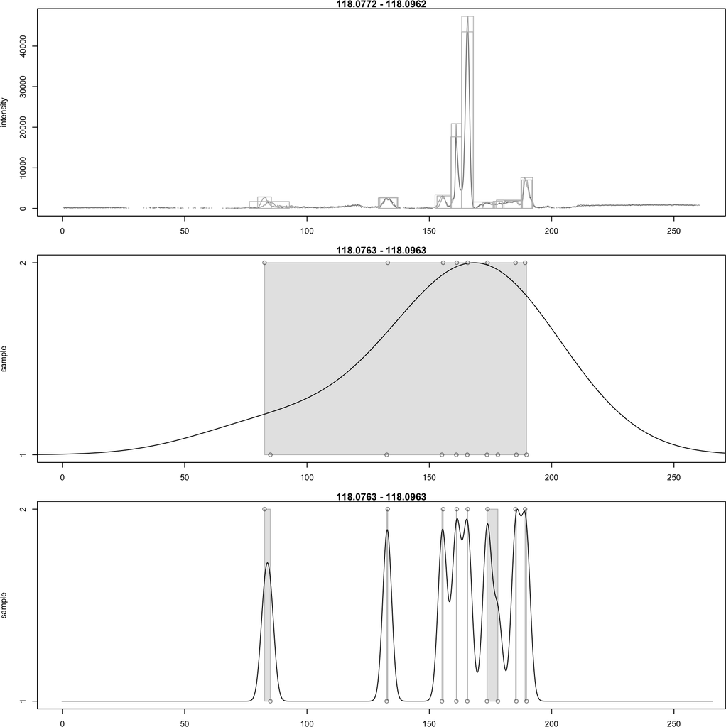

Figure 14: Define correspondence settings to separate Betaine and Valine peaks

```r
par(mfrow = c(3, 1), mar = c(3, 4.3, 1, 1))

## Plot the chromatogram for an m/z slice containing Betaine and Valine
mzr <- 118.08625 + c(-0.01, 0.01)
plot(chromatogram(data_cent, mz = mzr, aggregationFun = "max"))
highlightChromPeaks(data_cent, mz = mzr, whichPeaks = "apex_within")

## Correspondence in that slice using default settings
pdp <- PeakDensityParam(sampleGroups = data_cent$group)
plotChromPeakDensity(data_cent, mz = mzr, param = pdp, type = "apex_within")

## Reducing the bandwidth
pdp <- PeakDensityParam(sampleGroups = data_cent$group, bw = 1.8)
plotChromPeakDensity(data_cent, mz = mzr, param = pdp, type = "apex_within")
```

While with default settings all peaks in the m/z slice were grouped into a single feature, reducing `bw` to 1.8 resulted in separate features for all isomers. Below we perform the correspondence using the data-set specific settings.

```r
pdp <- PeakDensityParam(sampleGroups = data_cent$group, bw = 1.8,
                        minFraction = 0.4, binSize = 0.02)

## Perform the correspondence analysis
data_cent <- groupChromPeaks(data_cent, param = pdp)
```

Correspondence analysis results should also be evaluated on some known compounds. We thus check the results for another m/z slice that contains isomers Leucine and Isoleucine ([M+H]+ m/z 132.10191). Setting `simulate = FALSE` in `plotChromPeakDensity` will show the actual results from the correspondence analysis.

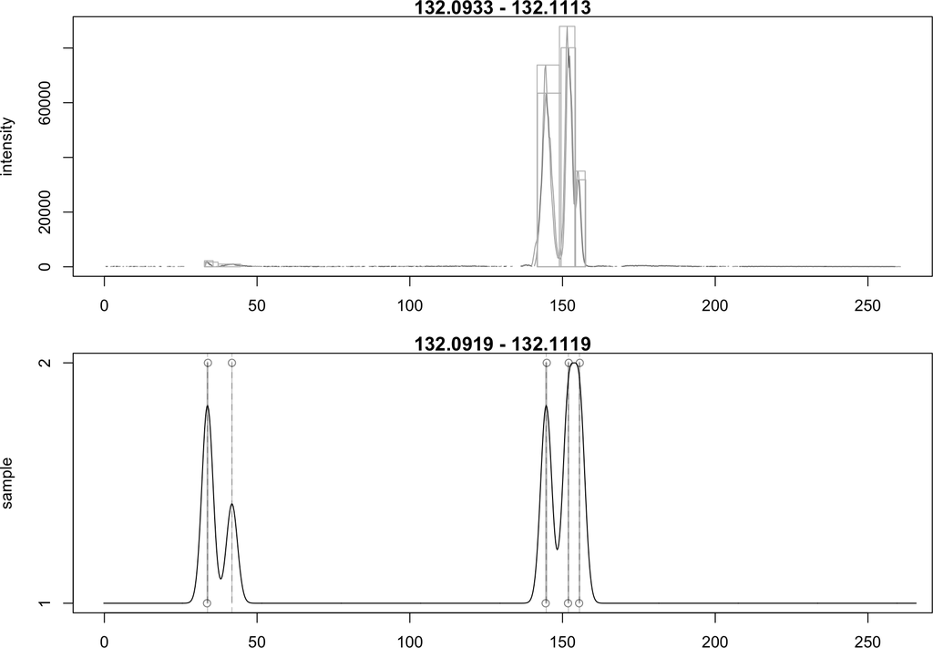

Figure 15: Result of correspondence on a slice containing the isomers Leucine and Isoleucine

```r
par(mfrow = c(2, 1), mar = c(3, 4.3, 1, 1))

## Plot the chromatogram for an m/z slice containing Leucine and Isoleucine
mzr <- 132.10191 + c(-0.01, 0.01)
plot(chromatogram(data_cent, mz = mzr, aggregationFun = "max"))
highlightChromPeaks(data_cent, mz = mzr, whichPeaks = "apex_within")

plotChromPeakDensity(data_cent, mz = mzr, param = pdp, type = "apex_within",
                     simulate = FALSE)
```

Despite being very close, peaks of isomers were successfully grouped into separate features. The results from the correspondence analysis can be accessed with the `featureDefinition` function. This function returns a data frame with the rt and m/z ranges of the apex positions from the peaks assigned to the feature and their respective indices in the `chromPeaks` matrix.

```r
## Definition of the features
featureDefinitions(data_cent)
```

```
## DataFrame with 373 rows and 9 columns
##                  mzmed            mzmin            mzmax            rtmed
##              <numeric>        <numeric>        <numeric>        <numeric>
## FT001 105.041765759115   105.0417381237  105.04179339453 167.690828441715
## FT002 105.041534700049 105.041534700049 105.041534700049 157.678493020291
## FT003 105.069695007544 105.069127922154 105.070262092934 31.8102637269468
## FT004  105.11027064078 105.110017017556 105.110524264004 63.7497685006848
## FT005 105.473356183272 105.473263747591 105.473448618952 205.889730352414
## ...                ...              ...              ...              ...
## FT369 133.929034853004 133.928683953998  133.92938575201 193.352469082405
## FT370  133.95581534453 133.955590320687 133.956040368373 199.064189470879
## FT371 133.960497992187 133.960206489125  133.96078949525  30.833162693146
## FT372 133.972794276215 133.972754801636 133.972833750795  206.86375484864
## FT373 133.974012650623 133.974012650623 133.974012650623 201.504155299324
##                  rtmin            rtmax    npeaks      POOL     peakidx
##              <numeric>        <numeric> <numeric> <numeric>      <list>
## FT001 167.461570484448 167.920086398982         2         2 c(125, 431)
## FT002 157.678493020291 157.678493020291         1         1         124
## FT003 31.6716433762194 31.9488840776743         2         2  c(20, 335)
## FT004 63.4556957920855 64.0438412092841         2         2  c(46, 367)
## FT005 205.797440382501 205.982020322326         2         2 c(273, 606)
## ...                ...              ...       ...       ...         ...
## FT369 193.346209881706 193.358728283105         2         2 c(256, 550)
## FT370 198.972615208277  199.15576373348         2         2 c(244, 585)
## FT371 30.8277988370971 30.8385265491949         2         2   c(8, 324)
## FT372 206.353905400883 207.373604296396         2         2 c(283, 639)
## FT373 201.504155299324 201.504155299324         1         1         640
```

Also, we can calculate simple per-feature summary statistic with the `featureSummary` function. This function reports for each feature the total number and the percentage of samples in which a peak was detected and the total numbers and percentage of these samples in which more than one peak was assigned to the feature.

```r
## Per-feature summary.
head(featureSummary(data_cent))
```

```
##       count perc multi_count multi_perc        rsd
## FT001     2  100           0          0 0.01492685
## FT002     1   50           0          0         NA
## FT003     2  100           0          0 0.22934418
## FT004     2  100           0          0 0.17149504
## FT005     2  100           0          0 0.04142419
## FT006     2  100           0          0 0.33421678
```

The matrix with the feature intensities can be extracted with the `featureValues` function. This function uses the feature definitions to extract the requested value from each chromatographic peak assigned to the feature and returns a matrix with rows being features and columns samples. The function takes two additional parameters `value` and `method`: `value` defines the column in the `chromPeaks` table that should be reported, and `method` the approach to handle cases in which more than one peak in a sample is assigned to the feature. Below we set `value = "into"` to extract the total integrated peak area and `method = "maxint"` to report the peak area of the peak with the largest intensity for features with multiple peaks in a sample.

```r
## feature intensity matrix
fmat <- featureValues(data_cent, value = "into", method = "maxint")
head(fmat)
```

```
##       20171016_POOL_POS_1_105-134.mzML 20171016_POOL_POS_3_105-134.mzML
## FT001                        3159.7569                         3093.752
## FT002                        4762.3987                               NA
## FT003                         744.8752                         1033.232
## FT004                       20211.2634                        15839.550
## FT005                       10220.8762                        10837.710
## FT006                       19653.1073                        31816.844
```

Among the first rows in that matrix we can spot an `NA` value. No peak was assigned to the feature *FT002* in the second sample, either because peak detection failed in that sample, or the corresponding ion is not present in that sample. With the `fillChromPeaks` function, `xcms` provides the functionality to *fill-in* missing peak data from the feature area (which is defined by the median rt and m/z of all peaks assigned to the feature). Several settings allow to increase this feature region in m/z and/or retention time dimension: `expandMz` and `expandRt` expand the region relative to the width of the area in either m/z or rt dimension. `expandMz = 1` would for example expand the regions by half of each feature’s m/z width on both sides hence resulting in regions with an m/z width twice as big as the original width. Finally, `ppm` allows to expand the m/z width of each region by an m/z dependent value. Note that in future the function will gain two more settings `fixedMz` and `fixedRt` to enable expansion of the feature area also by a constant value. Below we first determine the number of missing values in the data matrix and subsequently use `fillChromPeaks` to fill-in some missing peaks.

```r
## Number of missing values
sum(is.na(fmat))
```

```
## [1] 137
```

```r
## Define the settings for the fill-in of missing peaks
fpp <- FillChromPeaksParam(expandMz = 0.5, expandRt = 0.5, ppm = 20)
data_cent <- fillChromPeaks(data_cent, param = fpp)

## How many missing values after
sum(is.na(featureValues(data_cent)))
```

```
## [1] 4
```

```r
fmat_fld <- featureValues(data_cent, value = "into", method = "maxint")
head(fmat_fld)
```

```
##       20171016_POOL_POS_1_105-134.mzML 20171016_POOL_POS_3_105-134.mzML
## FT001                        3159.7569                         3093.752
## FT002                        4762.3987                         5844.158
## FT003                         744.8752                         1033.232
## FT004                       20211.2634                        15839.550
## FT005                       10220.8762                        10837.710
## FT006                       19653.1073                        31816.844
```

With `fillChromPeaks` we could *rescue* signal for all but 4 features with missing values. Note that filled-in peak information can also be removed any time with the `dropFilledChromPeaks` function. Also, setting `filled = FALSE` in the `featureValues` function would return only data from detected peaks.

The data analysis would now continue on the feature matrix and could comprise normalization of the abundances, identification of the compounds and differential abundance analysis.

One final thing worth mentioning is that `XCMSnExp` objects keep, next to the preprocessing results, also a history of all processing steps that have been performed with it. This can be accessed with the `processHistory` function.

```r
## Overview of the performed processings
processHistory(data_cent)
```

```
## [[1]]
## Object of class "XProcessHistory"
##  type: Peak detection
##  date: Fri Jul  6 12:44:27 2018
##  info:
##  fileIndex: 1,2
##  Parameter class: CentWaveParam
##  MS level(s) 1
##
## [[2]]
## Object of class "XProcessHistory"
##  type: Peak grouping
##  date: Fri Jul  6 12:44:32 2018
##  info:
##  fileIndex: 1,2
##  Parameter class: PeakDensityParam
##
## [[3]]
## Object of class "XProcessHistory"
##  type: Retention time correction
##  date: Fri Jul  6 12:44:33 2018
##  info:
##  fileIndex: 1,2
##  Parameter class: PeakGroupsParam
##  MS level(s) 1
##
## [[4]]
## Object of class "XProcessHistory"
##  type: Peak grouping
##  date: Fri Jul  6 12:44:39 2018
##  info:
##  fileIndex: 1,2
##  Parameter class: PeakDensityParam
##
## [[5]]
## Object of class "XProcessHistory"
##  type: Missing peak filling
##  date: Fri Jul  6 12:44:41 2018
##  info:
##  fileIndex: 1,2
##  Parameter class: FillChromPeaksParam
```

Also all parameter objects defining the settings for each analysis step are stored internally. Below we access for example the parameter object from the first preprocessing step.

```r
## Access the parameter class for a processing step
processParam(processHistory(data_cent)[[1]])
```

```
## Object of class:  CentWaveParam
## Parameters:
##  ppm: 30
##  peakwidth: 2, 10
##  snthresh: 10
##  prefilter: 3, 100
##  mzCenterFun: wMean
##  integrate: 1
##  mzdiff: -0.001
##  fitgauss: FALSE
##  noise: 0
##  verboseColumns: FALSE
##  roiList length: 0
##  firstBaselineCheck TRUE
##  roiScales length: 0
```

[output not shown]

[output cut: 43 more lines]

[output not shown]

# References

Conley, Christopher J, Rob Smith, Ralf J O Torgrip, Ryan M Taylor, Ralf Tautenhahn, and John T Prince. 2014. “Massifquant: open-source Kalman filter-based XC-MS isotope trace feature detection.” *Bioinformatics* 30 (18): 2636–43.

Gatto, Laurent, and Kathryn S Lilley. 2012. “MSnbase-an R/Bioconductor package for isobaric tagged mass spectrometry data visualization, processing and quantitation.” *Bioinformatics* 28 (2): 288–89.

Katajamaa, Mikko, Jarkko Miettinen, and Matej Oresic. 2006. “MZmine: toolbox for processing and visualization of mass spectrometry based molecular profile data.” *Bioinformatics* 22 (5): 634–36.

Prince, John T, and Edward M Marcotte. 2006. “Chromatographic alignment of ESI-LC-MS proteomics data sets by ordered bijective interpolated warping.” *Analytical Chemistry* 78 (17): 6140–52.

Smith, Colin A, Elizabeth J Want, Grace O’Maille, Ruben Abagyan, and Gary Siuzdak. 2006. “XCMS: processing mass spectrometry data for metabolite profiling using nonlinear peak alignment, matching, and identification.” *Analytical Chemistry* 78 (3): 779–87.

Smith, Rob, Andrew D Mathis, Dan Ventura, and John T Prince. 2014. “Proteomics, lipidomics, metabolomics: a mass spectrometry tutorial from a computer scientist’s point of view.” *BMC Bioinformatics* 15 Suppl 7 (Suppl 7): S9.

Tautenhahn, Ralf, Christoph Böttcher, and Steffen Neumann. 2008. “Highly sensitive feature detection for high resolution LC/MS.” *BMC Bioinformatics* 9 (1): 504.